# Impact of Education on Entrepreneurship - Data Gathering and Analysis

Samuel Dundon and Thierry Racaud

November 14, 2014

*Introduction to Collaborative Social Science Data Analysis*

#### Research Question

To what extent do the behavioral characteristics of education systems - individualistic, group-oriented, self-esteem reinforcing - affect the rate of entrepreneurship in OECD countries?

#### Estimation Strategy

##### Causal Chain

Education system / Teaching reinforcing self-esteem —> higher degree of individual self-esteem —> higher probability an individual will become an entrepreneur —> higher rate of entrepreneurship at a country-level.

##### Dependent Variables: Explaining the Country-level Rate of Entrepreneurship

We have examined three dimensions of entrepreneurship to prepare for this stage of the project, established entrepreneurship in the country, nascent entrepreneurship (less than three months), and entrepreneurial intention. We will study each of these successively as we may well observe different effects.

To measure these three dimensions of entrepreneurship, we have used three [Global Entrepreneurship Monitor (GEM)](http://www.gemconsortium.org) indicators:

- Established Business Ownership Rate (Percentage)
- Nascent Entrepreneurship Rate (Percentage)
- Entrepreneurial intention Rate (Percentage)

##### Key Explanatory Variable: Degree of Self-esteem Reinforcement within the Education System

As Inglehart has shown how personal values are shaped before the age of 20, we will try to show how compulsory education (from 6 to 16 years of age) shapes individuals, especially in terms of self-esteem. To do so, we decided to incorporate GEM indicators that relate to self-esteem and confidence. First, we included GEM survey data on the average “perceived capabilities” of an individual (18-64) in a given country to start a business. Second, we included additional GEM data on how the “fear of failure” could deter an average individual (18-64) in a country to become an entrepreneur. Both of these data sets indicate the average percentage for each characteristic at the country-level.

##### Control Variables: Controlling for Classic Determinants of Entrepreneurship

To control for the general state of the economy, we included annual GDP Growth from the World Bank [World Development Indicators](http://data.worldbank.org/data-catalog/world-development-indicators) as a control variable in our regression equations. In addition, we included a GEM indicator called “Perceived Opportunities.” For each country, it is the average percentage of individuals who believe there are opportunities to start a business in their area. Since we look at average individual self-esteem in every OECD country, we believe it is appropriate to look at the opportunities perceived by the average 18-64-year-old individual in these countries.

In the future, we may revise this to include lagged GDP growth in recognition of the time taken for governments and individuals to react to the state of the economy, and are planning to include control variables from GEM. Specifically, we intend to control for the classic determinants of entrepreneurship – economic and structural determinants. To do so, we will add the following nine key entrepreneurship conditions as defined in the GEM [National Experts Survey (NES)](http://www.gemconsortium.org/Data-Collection).

1. Finance
2. Government policies
3. Government programs
4. Entrepreneurial Education and Training
5. Research and Development Transfer (R & D)
6. Commercial and professional infrastructure
7. Internal Market openness
8. Physical infrastructure and services
9. Cultural and social norms

##### Regressions

The following equations were used to determine the relationship between our dependent and explanatory variables:

The variables *Percent Fear* and *Percent Opportunities* were included as an interaction term $PercentFear*PercentOpportunities$ because of the design of the survey. PercentFear is: “the Percentage of 18-64 population with positive perceived opportunities who indicate that fear of failure would prevent them from setting up a business.”

#### Data Collection and Cleaning

To collect the data necessary to run these regression equations, we downloaded *.csv* data from GEM and used the WDI API to obtain the necessary annual GDP growth of OECD Countries.

**Necessary R Packages**

The following packages were needed to complete the data collection portion of this assignment:

- repmis
- tidyr
- reshape
- plyr
- WDI

**GEM Data**

GEM data was embedded in an interactive database and was difficult to extract automatically without writing a program. To simplify this process, we downloaded the necessary *.csv* files and saved them in our GitHub repository (to reduce complexity, we deleted the first three unnecessary rows before saving). We then linked to the RAW version of the files and added the code required to load them from *R*. The repmis package is required to load these documents from the repository.

Cleaning the GEM data required deleting unnecessary characters in the year columns, changing the years from columns to rows (changing the data from wide to long), and changing the column names to describe which data was being analyzed. In the process of doing this we created new data sets for each of these survey questions, which were called C*dataset* (clean followed by the data set name). This was done for each of the six GEM data sets before merging these sets two at a time to create the data set *FinalGEM*.

**World Bank Data**

As mentioned above, one of our control variables, annual GDP growth, was obtained using the WDI API from the World Bank. Using this API, we accessed GDP data from all the OECD countries directly from *R*. To clean this data, we used *plyr* to change the variable names then recoded the U.S. and South Korea country names to maintain consistency with the GEM data set and dropped an unnecessary column that was not included with the GEM data.

Finally, we merged the annual GDP growth data with the *FinalGEM* data set to create *CompleteDataset*. This is the data set used to run the regressions and generate the charts and figures outlined in this document. To reduce complexity in the environment we also included a command to remove unnecessary objects in the environment.

#### Data Analysis

**Linear Regression Estimates**

|  | *Dependent variable:* |  |  |
| --- | --- | --- | --- |
|  | National Level Average Percent Entrepreneurial Intention | National Level Nascent Entrepreneural Activity | National Level Average Percent Owning a Business |
|  | (1) | (2) | (3) |
| National Level Avg Perceived Capabilities | 0.10* | 0.03 | 0.13*** |
|  | (0.05) | (0.02) | (0.03) |
| National Level Avg Fear of Failure | 0.25** | 0.05 | 0.08 |
|  | (0.11) | (0.04) | (0.07) |
| National Level Avg Perceived Good Opportunities | 0.23** | 0.06* | 0.01 |
|  | (0.09) | (0.04) | (0.06) |
| Way of Teaching | 0.63 | 0.11 | -0.53 |
|  | (0.96) | (0.40) | (0.65) |
| Austria | -4.40 | -3.97*** | -8.35*** |
|  | (3.33) | (1.45) | (2.35) |
| Belgium | -3.07 | -4.29*** | -8.10*** |
|  | (2.01) | (0.84) | (1.36) |
| Canada | -3.34* | -1.52* | -6.00*** |
|  | (1.96) | (0.84) | (1.36) |
| Chile | 17.30*** | 0.81 | -7.18*** |
|  | (2.00) | (0.83) | (1.35) |
| Czech Republic | 0.19 | -0.33 | -5.59** |
|  | (3.29) | (1.44) | (2.34) |
| Denmark | -3.94** | -4.54*** | -4.56*** |
|  | (1.92) | (0.80) | (1.29) |
| Finland | -5.04*** | -4.15*** | -2.44* |
|  | (1.84) | (0.77) | (1.25) |
| France | 0.84 | -3.78*** | -8.65*** |
|  | (2.82) | (1.16) | (1.88) |
| Germany | -3.93* | -3.74*** | -7.02*** |
|  | (1.99) | (0.82) | (1.33) |
| Greece | 0.99 | -3.21*** | -1.10 |
|  | (2.17) | (0.85) | (1.38) |
| Hungary | 0.02 | -2.56*** | -6.29*** |
|  | (2.16) | (0.90) | (1.46) |
| Iceland | 4.34** | 0.07 | -3.02** |
|  | (1.77) | (0.75) | (1.21) |
| Ireland | -3.39** | -2.38*** | -4.26*** |
|  | (1.69) | (0.69) | (1.12) |
| Israel | 4.16** | -3.84*** | -7.72*** |
|  | (2.06) | (0.82) | (1.38) |
| Italy | -2.43 | -4.39*** | -6.74*** |
|  | (1.95) | (0.79) | (1.29) |
| Japan | -3.64 | -4.40*** | -2.63 |
|  | (3.18) | (1.33) | (2.16) |
| Korea (South) | 6.26*** | -2.63*** | -0.08 |
|  | (2.31) | (0.95) | (1.54) |
| Mexico | 10.22*** | 1.40* | -9.62*** |
|  | (2.05) | (0.83) | (1.35) |
| Netherlands | -5.27*** | -4.38*** | -4.77*** |
|  | (1.93) | (0.80) | (1.31) |
| New Zealand | -0.35 | 1.17 | -2.01 |
|  | (2.05) | (0.83) | (1.34) |
| Norway | -3.11* | -2.82*** | -3.64*** |
|  | (1.85) | (0.78) | (1.27) |
| Poland | 7.26** | -3.41** | -4.17* |
|  | (3.21) | (1.40) | (2.27) |
| Portugal | -3.65 | -4.80*** | -6.77*** |
|  | (2.69) | (1.04) | (1.69) |
| Slovenia | -1.21 | -4.24*** | -6.59*** |
|  | (1.80) | (0.76) | (1.23) |
| Spain | -5.38*** | -4.28*** | -5.37*** |
|  | (1.90) | (0.75) | (1.21) |
| Sweden | 0.86 | -5.31*** | -4.67*** |
|  | (2.24) | (0.89) | (1.44) |
| Switzerland | -2.28 | -3.60*** | -3.99*** |
|  | (1.91) | (0.81) | (1.31) |
| Turkey | 9.51*** | -4.57*** | -4.32*** |
|  | (2.08) | (0.89) | (1.43) |
| United Kingdom | -5.05*** | -4.13*** | -6.73*** |
|  | (1.76) | (0.72) | (1.17) |
| United States | -2.58 | -0.48 | -6.56*** |
|  | (1.71) | (0.70) | (1.14) |
| National Level Avg Fear of Failure x National Level Avg Perceived Good Opportunities | -0.01** | -0.001 | -0.002 |
|  | (0.003) | (0.001) | (0.002) |
| (Intercept) | -5.22 | 3.05 | 5.97 |
|  | (5.90) | (2.44) | (3.97) |
| Observations | 175 | 196 | 195 |
| R<sup>2</sup> | 0.85 | 0.78 | 0.66 |
| Adjusted R<sup>2</sup> | 0.81 | 0.74 | 0.58 |
| Residual Std. Error | 2.85 (df = 139) | 1.27 (df = 160) | 2.06 (df = 159) |
| F Statistic | 22.11*** (df = 35; 139) | 16.67*** (df = 35; 160) | 8.79*** (df = 35; 159) |
| *Note:* | p<0.1; p<0.05; p<0.01 |  |  |

National-level average of people perceiving opportunities but acknowledging fear of failure will prevent them from creating a business (FF)

**Simulation Package and Cleaning**

In addition to the output table, a simulation is helpful to visually illustrate the relationship the probability of obtaining a given value in the dependent variables conditional on change in the independent variable. We used the *Zelig* package to run a least square regression and generate a simulation of equation 1. Prior to running this regression, however, we ran the na.omit command to remove omitted variables from the equation.

To examine the probabilities of achieving given outcomes, we generated three simulations for the first regression equation. To demonstrate this method, we have included one simulation below.

**Process**

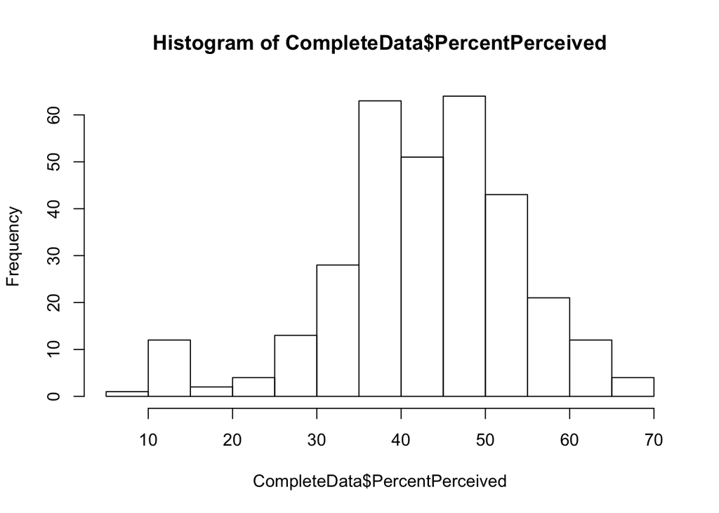

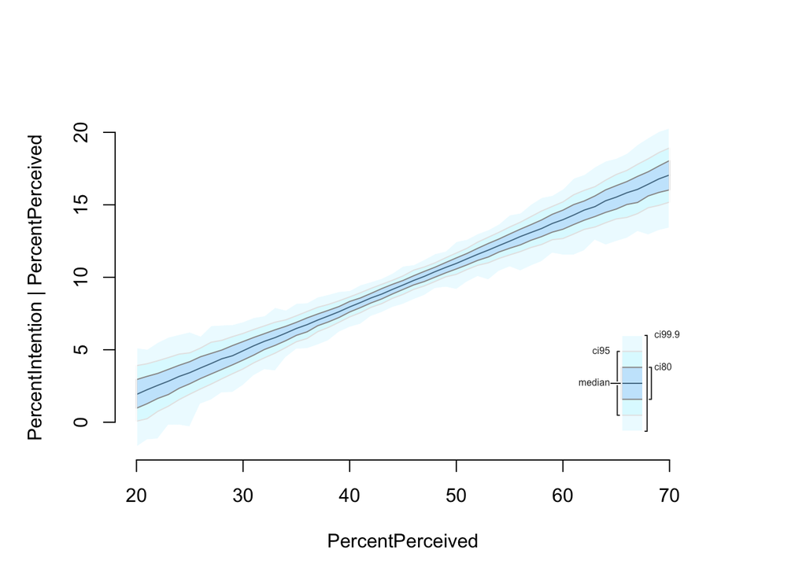

#### Outlook

Going forward, we are considering adding one of the six questions used by GEM to measure the importance of entrepreneurial education at the country level in its NES Survey. Item D01 states “in my country, teaching in primary and secondary education encourages creativity, self-sufficiency, and personal initiative.” This could be a proxy to get a sense of how supportive of self esteem a given education system is.

We may also want to quantify how individualistic or group-oriented an average student is by the end of compulsory education, as the literature holds social inclusion as an explanatory factor for self-esteem. We will use OECD PISA data on “the sense of belonging” for this.

Next steps will also include looking more thoroughly into control variables and determining the most appropriate way to present our results. To do so we may need to extract data from various national NES reports and put together a table, as it does not seem to exist as such.

| Statistic | N | Mean | St. Dev. | Min | Max |
| --- | --- | --- | --- | --- | --- |
| PercentFear | 318 | 33.928 | 7.982 | 10 | 61 |
| PercentNascent | 318 | 4.329 | 2.505 | 0.400 | 15.400 |
| PercentPerceived | 318 | 43.186 | 11.065 | 9 | 67 |
| PercentOwner | 317 | 6.414 | 2.931 | 0.400 | 28.000 |
| PercentIntention | 295 | 10.299 | 6.951 | 0.700 | 46.500 |
| PercentOpportunities | 318 | 33.931 | 15.168 | 3 | 71 |
| AnnualGDPGrowth | 442 | 2.037 | 3.071 | -14.098 | 10.494 |